# Project 3: Bioinformatics of Gene Expression

Merrimack College DSE6630: Healthcare & Life Sciences Analytics

Desi Spark (DS), Meghan Holden (MH)

21 June 2026

# 1 Background to the Project

## 1.1 Overview

At the end of Demo_3, you hopefully concluded that the SVM was performing better than the Random Forest algorithm, at least OOB. But the biggest problem we saw with both algorithms is sign of **overfitting**: when the testing error was higher than the training error (i.e., testing accuracy < training accuracy). Well, thankfully, we can address this with **cross-validation** and **tuning the hyperparameters**.

## 1.2 Overfitting

When we optimize the model for the training data, our model will score very well on the training set. We expect this to be true (if it doesn’t, then training failed!). However, there may be times when the model in turn is not **generalizable**, meaning that it does not perform nearly as well on the test data set. When a model performs highly on the training set but poorly on the test set, this is known as **overfitting**. We have created a model that knows the training set very well but cannot be applied to new problems. Many textbooks use this analogy of overfitting, and I think it works very well: > We all knew a student in school who could memorize information, like answers to a quiz, but failed to apply those concepts in the real-world. That student’s mind was overfitted!

Therefore, an overfitted model can look great on the training set but will be useless on other data because it is not generalizable. As mentioned above, we do have two keys ways of helping with this, though.

## 1.3 Cross-validation

You may have encountered $k$-fold CV before, in which case, excellent - you will already have a sense for what we are doing and why. But, if not, let’s have a gentle introduction to cross-validation. You are all already familiar with the idea that we split our dataset into a training and a testing set. $k$-fold CV further splits the training set into a $k$ number of subsets also called **“folds”**. The model is fit iteratively $k$ times where each time the training set contains $k-1$ folds and the model is evaluated on the $k^{th}$ fold. The most commonly used folds on personal computers are $k = 5$ and $k = 10$ for 5% hold-out and 10% hold-out at each iteration, respectively, but you can fit up to $n-1$ folds if you have the computational resources, where $n$ is the number of observations!

## 1.4 Hyperparameter Tuning

What is a **hyperparameter**? Model parameters are those that are learned during training, e.g., the slope and intercept in a linear regression. Hyperparameters are external and not learned, and therefore must be set (or generated by default) by the data scientist before training. In the case of a random forest, hyperparameters include the the number of features considered by each tree when splitting a node for random forest or the kernel in SVM. Since the best hyperparameters are not something we can choose *a priori*, this is why we **tune the hyperparameters** as we train the model. This is done using trial-and-error, although there are some guidelines can often keep in mind to help ensure that we our models are on a good learning path.

As we (or the package we are using) performs the tuning, we are performing many iterations of the entire cross-validation process, whether that is $k$-fold or another CV method. We then compare all models, select the best one based on a performance metric (typically RMSE for regression or accuracy for classification), and train it on the full training set. Once we have our best model, we will then evaluate it on the testing set. Thus, even though you may not necessarily see all of the iterations involved, be aware of how extensive this process actually is!

## 1.5 Objectives

We will spend our final class session this term briefly discussing overfitting, cross-validation, and hyperparameter tuning in the context of project planning. From here down, I give you a demo how to tune the Random Forest we fit last week to the VST expression data for the bumblebee chill-coma experiment. **Your objective** will be to apply all the same methods to the SVM and compare and contrast your findings. Specifically, we will compare and contrast **nested cross-validation** versus **$k$-fold cross-validation** to see how well, if at all, we are able to overcome the **P >> n** problem we discussed in Demo_3.

## 1.5.2 Housekeeping

### 1.5.2.1 Loading Data

To make your life easier, we will load some pre-prepared datasets from our work in Demo_3. That way, we don’t need to spend the computational time running our DESeq and previous machine learning models all over again!

```r
load("C:/Users/User/Documents/GitHub/Merrimack_DSE6630/Merrimack_DSE6630/Team_Directories/epsilon/Module_Demos/Demo_3/vst_all_timepoints.Rdata")  ## These are the all time-points
                                            ## used for Demo_3
load("C:/Users/User/Documents/GitHub/Merrimack_DSE6630/Merrimack_DSE6630/Team_Directories/epsilon/Module_Projects/Project_3/data/DESeqResults.Rdata")                ## Load the results of the all time
                                            ## points DESeq analysis (so you
                                            ## don't have to run it again)
load("C:/Users/User/Documents/GitHub/Merrimack_DSE6630/Merrimack_DSE6630/Team_Directories/epsilon/Module_Projects/Project_3/data/OOB_RF_Importance.Rdata")   ## Load the OOB RF importance from
                                            ## Demo_3 for comparison
load("C:/Users/User/Documents/GitHub/Merrimack_DSE6630/Merrimack_DSE6630/Team_Directories/epsilon/Module_Projects/Project_3/data/OOB_SVM_Importance.Rdata")  ## Load the OOB SVM importance from
                                            ## Demo_3 for comparison
```

### 1.5.2.2 Functions

Similarly, I have written some functions to make your life easier. Although I do not require you to take the time to annotate them, it can be great practice in code reading to take a stab at trying to understand exactly *how* these functions do what they do.

#### 1. `doSplits()`

This function quickly and easily performs data partitioning & pre-processing of the datasets, depending on algorithm chosen. This function could also facilitate automated testing of filtering cutoffs or split-ratios by algorithm, if desired.

#### 2. `findOverlappingGenes()`

Function that compares the `DESeq` results at a given log-fold change (LFC) with the list of important genes from an ML classifier. This could again be iterated over to automate collation of results for more automated comparisons.

#### 3. `compareConfusion()`

This function compares the results of confusion matrices by printing them in a table side-by-side. You could also use this to graph your results, if desired.

# 2 Tuning the Random Forest Model

One of the reasons that random forest is generally considered to work so well OOB is that it picks up a portion of the predictors for training. At each step, it randomizes the variable selection during each tree split. Thus, it is doing its own form of cross-validation internally as part of the algorithm. This is also even the OOB is considered to be less prone to overfitting as compared to other machine learning algorithms.

That said, we can explicitly apply an external cross-validation too - **because even models that are more robust to overfitting are STILL capable of being overfitted.**

More importantly, though, there are certain **hyperparameters** of random forests that will assist with overfitting much better than cross-validation given the internal split-variable randomization of the algorithm.

**Note**: One of the other advantages to RF that you may come across is that it is *more* robust to multicollinearity. Why? Well, since the algorithm is randomly selecting a certain number of samples via bootstrapping to train on and another random sample of features at each split, then a more diverse set of trees is produced. It tends to lessen correlation among the trees and would have the potential to ‘break up’ multicollinearity in the process. However, being “more” robust is not the same thing as being perfectly robust! It is worth thinking this through if, for example, we expect similar **kinds** of genes to be expressed in response to chill coma.

## 2.1 Random Forest Hyperparameters

### 2.1.1 Number of features at any given split.

Each time a split is to be performed, the search for the split variable is limited to a random subset of the $p$ features. In R’s packages `randomForest` and `ranger`, this hyperparameter is called $m_{try}$ and is arguably one of the single most important hyperparameters to tune. By default, for regression RF, $m_{try} = \frac{p}{3}$ and for classification RF, $m_{try} = \sqrt{p}$.

But let’s think about that: our OOB random forest, by default, would have run an $m_{try} = \sqrt{12927}$ or $approx$ 113.6969657. Thus, $m_{try}$ is often one of the first hyperparameters you should consider tuning for random forest.

### 2.1.2 Number of trees in the forest.

**How many trees should you have in your forest?** Although this isn’t technically a hyperparameter, if you do not have enough trees in your forest, you will not be able for your model to **converge**, i.e., stabilize the error rate. Note that one of the cross-validation packages we will use, `train()` from the `caret` package does not allow us to tune **num.trees**. I will be showing you a work-around for that.

Also, note that [Hands-on Machine Learning in R](https://bradleyboehmke.github.io/HOML/random-forest.html) recommends starting with $num.trees = 10 \cdot p$, but the challenge for us is **how massive the computational time would be**. DO NOT ATTEMPT THIS! By these recommendations, you would set an $num.trees =$ 129270, which would only crash your computer!

**Instead, I am going to recommend an** $num.trees \leq 2000$ **unless you have wayyyy more computing power than I do at the moment ;).**

### 2.1.3 Complexity of each tree, aka, node split.

Whereas the number of features at any given split ($m_{try}$) allows us to control the learning of the algorithm, the node split allows us to control the complexity of the individual trees in the forest. The default values are typically 1 and 5 for classification and regression, respectively, and while the default can work well on many datasets, noisier datasets or those that require higher values of $m_{try}$ may perform better with **increased** values of node size. Increasing values of node size **decreases** complexity and thereby tree depth. Further, larger node sizes can often speed up computation without large sacrifices to error rates.

### 2.1.4 Splitting rule to use during tree construction.

The main rules we will be using are the **gini** rule and the **extratrees** rule. We will practice tuning these rules to see what effect, if any, they can have on forest construction and overall accuracy.

#### **Question 1**: Look up these rules and try to explain what they are doing for yourself.

MH

> The Gini index indicates the purity of a node (where a small value means only one, or minimal, classes make up the node). The Gini rule will choose the split that minimizes the variance. The larger the mtry, the more features the Gini rule will consider.

> Extra Trees (which, acording to Samy Baladram’s article in Medium (2024), stands for Extremely Randomized Trees) operates similar to Random Forest, but with more randomization such that it is not searching for optimal thresholds, but instead is making it splits randomly. It then assesses for the best outcomes of those random splits.

> Source: ISLR, v2, 2021 Source: https://medium.com/@samybaladram/extra-trees-explained-a-visual-guide-with-code-examples-4c2967cedc75

### Sampling scheme.

This would allow us to alter whether we are sampling features with or without replacement at each node split. We will not be tuning this at this time.

## 2.2 Pre-processing and feature selection

Two important elements of the data science life cycle that we did not have a chance to get into yet last week in Assignment 1 was **pre-processing** (which includes transformations, encoding, splitting, and normalizing) and **feature selection** (which includes reduction of the number of features or dimensionality of the dataset). We will spend more time on both of these topics throughout the course, but for this project it is largely hidden in the function that I wrote for us above, `doSplits()`.

#### **Question 2**: Take a moment to go look at the function and the documentation I have written. Also try playing with the parameters a bit - how many more or fewer genes do you get when you lower or raise the `filterCutoff`, respectively?

MH > The filter is based on the medians of the VST gene counts. The training dataset is set for medians that are greater than the `filterCutoff`. Therefore, when `filterCutoff` is lowered, more genes are included in the training set, whereas when `filterCutoff` is increased, less genese are included in the traininset. For example, when `filterCutoff` is set to 5, the number of genes in the training dataset are 7676, at 4 there are 9765, and at 6 there are 6120.

Notice in the comments that I am only doing feature selection on the training data set. Why? Current research strongly suggests that filtering on the entire dataset has the potential to generate bias, not surprisingly, which in turn can create **data leakage**. The advice of Vabalas et al. (2019) is to only do our feature selection **only on the training model**.

#### **Question 3a**: Do some research on **data leakage** and try to explain what that means in this context. Why do we care about data leakage?

DS > We should care about data leakage from our model could potentially be too optimistic, which will use data that it wouldn’t run into in the real scenarios. Certian types are: contamination of our Train-Test models, target leakage, and data processing leakage. These types would be caused by; improper data splitting, incorrect preprocessing workflow, using future or unavailable data, poor feature selections, data pipeline mistakes, and merging external data incorrectly. If we don’t properly validate our processes in analyzing the data, when not careful, could lead into false results. source:“https://www.geeksforgeeks.org/machine-learning/data-leakage/”

Now, we will set `filterCutoff = 5` and partition data for random forest tuning.

```r
splits <- doSplits(vst = vsData,
                   algorithm = "rf",
                   splitRatio = 0.8,
                   filterCutoff = 5)
```

```
## [1] "After filtering, number of genes in the dataset are: 7676"
```

```r
train <- splits[[1]]
test <- splits[[2]]
```

#### **Question 3b**: Using the annotation I have provided in the function `doSplits()`, explain the parameters chosen and try to explain *why* you think they were chosen, based on what we did in Demo_3. In particular, make sure to explain WHY a filterCutoff of 5 was chosen. (**Hint**: In Demo_3, did we do anything to adjust for genes with low variance in expression?)

DS > algorithm = “rf” is the specific model to use work with the data, random forest. splitRatio = 0.8; We’ll be using 80% of the data for training the model, and the remaining 20% for the testing the algorithm. filterCutoff = 5, This value of the parameter will drop any feature that are nearly constant which are variances that don’t change at all or aren’t useful. This will keep anything with an importance of 5 or higher. This is important for removing unwanted noise as well, so RF can perform even better.

## 2.3 Apply $k$-fold Cross-Validation (CV) to Random Forest

### 2.3.1. Leverage the `trainControl()` and `train()` functions from the `caret` package.

Recall that when were doing OOB random forest in Demo_3, we didn’t use `trainControl()`. That will be a deviation from what we do this time.

Howeverm let’s first fit the same RF we fit last week for comparison:

```r
rfOOB <- randomForest::randomForest(
  Treatment ~ .,
  data = train)

pred.test.rf <- predict(rfOOB, test, type = "response")
confMat <- confusionMatrix(pred.test.rf, test$Treatment)
```

### 2.3.2. Employ a $k$-fold CV where $k = 10$.

Set the control for $k = 10$ and then run the RF:

```r
# Set the CV arguments
kFoldCtrl <- trainControl(method = "cv",    ## for k-fold CV
                          number = 10)      ## k
```

And fit the Random Forest model:

```r
rfCV <- train(Treatment ~.,
               data = train,
               method = "ranger",
               trControl = kFoldCtrl)    ## added in the 10-fold CV
```

#### **Question 4**: Explain, in your own words, what a 10-fold CV does here. Is it vital to perform with a random forest? Why or why not?

MH > Cross validation is not vital to randomforest since it already includes out of bag (OOB) to demonstrate model suitibility; however, 10-fold cross validation can help increase confidence, and allows us to compare across other, non-treebased modesls. A 10-fold cross validation divides the training dataet into 10 equal parts and uses the first fold as a validation set and trains on the remianing 9, then repeated for the rest of the folds. Results are averaged to assess performance.  
Source: ISLR, v2, 2021

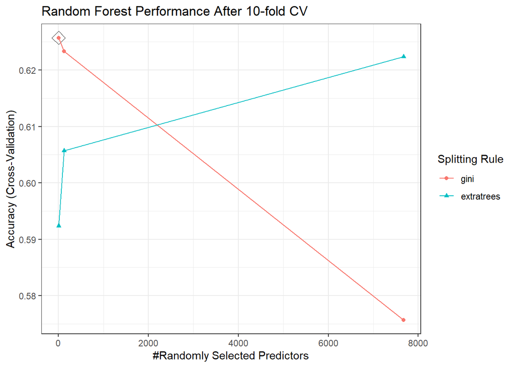

Figure 1. Visualize the 10-fold CV Performance

You’ll notice that by default with the 10-fold CV is that **it is doing automated hyperparameter tuning too!** Also, note the x-axis here. It is actually the $m_{try}$ hyperparameter, the number of randomly selected predictors $P$ at each split. This allows us to **visualize the effect of** $m_{try}$ **on accuracy.**

#### **Question 5**: What combination of hyperparameters gives the highest accuracy in the **training model**? (Use plot above to answer.)

DS > The Gini model.

### 2.3.3. Extract best model.

You can also extract the best model as well to get the precise combination of hyperparameters.

Table 1. Hyperparameters of the best Random Forest Model using 10-fold CV

| mtry | splitrule | min.node.size |
| --- | --- | --- |
| 2 | gini | 1 |

### 2.3.4. Assess for model stability.

Let’s look at the fold-specific results for our best model. This is essential to assess **stability** of the model.

Table 2. Fold-specific accuracy for the 10-fold CV Random Forest

| Accuracy | Kappa | Resample |
| --- | --- | --- |
| 0.8333333 | 0.6666667 | Fold09 |
| 0.5000000 | 0.0000000 | Fold05 |
| 0.6666667 | 0.3333333 | Fold01 |
| 0.2857143 | -0.5217391 | Fold07 |
| 0.5000000 | 0.0000000 | Fold10 |
| 0.6000000 | 0.2857143 | Fold03 |
| 0.6666667 | 0.3333333 | Fold06 |
| 0.8333333 | 0.6666667 | Fold04 |
| 0.5714286 | 0.0869565 | Fold02 |
| 0.8000000 | 0.5454545 | Fold08 |

#### **Question 7**: What is the average, minimum, and maximum accuracy values across the ten folds? What does this tell you about the **stability** of the random forest? Is this concerning? Make sure to discuss reasons why there may be instability, if that’s the conclusion you draw.

**Hint**: Think about these results relative to our **sample size**. Would we expect instability in resampling from, among other issues, small sample size alone in this case?

### 2.3.5. Fit the test data to the best tuned model from the 10-fold CV.

Regardless of the decision you made in Question 7, let’s proceed with assessing model performance.

```r
rfCV <- train(Treatment ~.,
               data = train,
               method = "ranger",
               trControl = kFoldCtrl,
               tuneGrid = rfCV$bestTune)   ## Add in the results of the CV
                                           ## and auto tuning

pred.test.rf <- predict(rfCV, test, type = "raw")  ## type is now 'raw'
## Store the confusion matrix for later comparison
confMatCV <- confusionMatrix(pred.test.rf, test$Treatment)
```

### 2.3.6. Compare the two confusion matrices.

Lastly, let’s compare the results of what we just ran (stored in `confMatCV`) with what we the OOB performance from Demo_3 (stored in `confMat`).

Table 2. Comparing Accuracy - Random Forest

| Metric | Confusion Matrix 1 | Confusion Matrix 2 |
| --- | --- | --- |
| Accuracy | 0.7142857 | 0.7142857 |
| Kappa | 0.4285714 | 0.4285714 |
| AccuracyLower | 0.4189647 | 0.4189647 |
| AccuracyUpper | 0.9161107 | 0.9161107 |
| AccuracyNull | 0.5000000 | 0.5000000 |
| AccuracyPValue | 0.0897827 | 0.0897827 |
| McnemarPValue | 0.6170751 | 0.1336144 |

#### **Question 8**: Let’s take a moment to unpack what we are looking at here. What do each of these metrics measure? **Hint**: Make sure to look at the documentation for the `confusionMatrix()` function from `caret`.

DS > **Accuracy**: This is the proportion of correct predicitions of True positive to true positive.

> **Kappa**: This is the sensitivity measurement where it determines the agreement beyond chance, meaning it calculates if this model is better than random guessing.

> **Accuracy Lower Bound**: This would be the detection rate which is the proportionality of correctly identified positive cases in the lower end of the range.

> **Accuracy Upper Bound**: This is the same as above but on the max range of accuracy.

> **Accuracy Null**: This is the controlled cases that are inside the data. So roughly 50% of the data have controlled cases.

> **McNemar p-value**: This is to test if there weren’t any asymmetry errors at all. In this case there aren’t any of those errors. The outcome of the function only looks for false negative and positives and sees if there are any bias errors within our results.

#### **Question 9**: What was the impact, if any, of the pre-processing we performed here? What evidence do you have? Lastly, what was the biggest change, other than tuning, that we made as compared to the OOB RF?

DS >For the differences we made were taking a different approach to the splitting rules for the Random Forest along with using K-folds for Cross validation. We’re using m{try} values which dictate the amount is a good split point to seperate the classes of information. There was another variable when filtering out data with the filtercutoff that’ll exclude data points that were more at a constant rate.

#### **Question 10**: What are your conclusions, at this stage, about the performance of the 10-fold CV, tuning, and applying the filtering cutoff relative to the OOB performance from Demo_3?

DS > With the given matrix results from above the Accuracy p-value is higher than .05 (5%) meaning we can’t know for sure if this even better than randomly guessing. For Kappa the model has some imbalanced predictions since it’s value is lower than .50 (50%). This isn’t a good model as of right now since it misses the controlled cases 4 / 7 times! It is interesting to see that the control cases, when the model says it is, are 100% accurate. Seems a bit weird to have an outcome like this in my opinion. With the McNemar’s test is heavily biased towards the false negatives, but we have to remember sicne the sample size is small, it’s not statistically significant. It seems to have not really gotten too much better than the previous model.

## 2.4 Further Tuning: Searching

Hyperparameter tuning is akin to looking for a needle in a haystack. Each model we fit will have its own set of unique hyperparameters, and thus they are not something that you can “guess” or “estimate”. Thus, the only approach to narrow our search is to evaluate a wide range of values for each hyperparameter (kind of like setting fire to the haystack, computationally speaking). We can allow packages like `caret` to automatically search for us (as we just did), but if the goal is to generate the most exhaustive search of hyperparameters - and in a way that is agnostic to human error - we need to do a **search**. Searches come in several flavors, but we will be executing a **grid** search vs. a **random** search for our study because both are quite simple to execute with the packages we already have.

### 2.4.1 Grid Search

As the name suggests, grid searches take a matrix of values and will iteratively and linearly search through the grid until all combinations have been tested. This is also sometimes referred to as a ‘Cartesian grid’ search.

##### How many searches to do?

You will always be limited by time & computational resources. As much as I would like this to be exhaustive, for our purposes we will be keeping this smaller and more manageable since we are not running it on a computing cluster or in parallel.

##### A Note about Randomness

You may have already noticed that you get different results from your teammates or even if you run it yourself over and over. Why? By default, `caret` is setting a random seed for each split, and so you could have a different set of seeds than someone else (or even versus when you run it again). Wait, that’s not terribly helpful, is it?

It is and it isn’t. You might imagine times when you just want to be able to run a model, check the fit, and move on. Other times, like this time, we need something highly reproducible. `caret` will allow us to set our seeds so that we can force it to be more reproducible. Once we have some seeds to add, we update the `kFoldctrl` object.

**NOTE**: When you strike out on your own, you may get a ‘bad seeds’ error. This is often because you need to increase the size of your sample space.

#### 2.4.1.1. Set the search grid.

```r
searchGrid <- expand.grid(
  mtry = floor(ncol(train) * c(.05, .15, .25, .35, .45)),
  splitrule = c("gini", "extratrees"),
  min.node.size = c(1, 3, 5, 10)
)
```

#### 2.4.1.2. Run the RF, this time adding in the search grid.

Be patient. This may take a few minutes to run.

```r
rfTuned <- train(Treatment ~.,
               data = train,
               method = "ranger",
               trControl = kFoldCtrl,
               tuneGrid = searchGrid # Add in the search grid
)
```

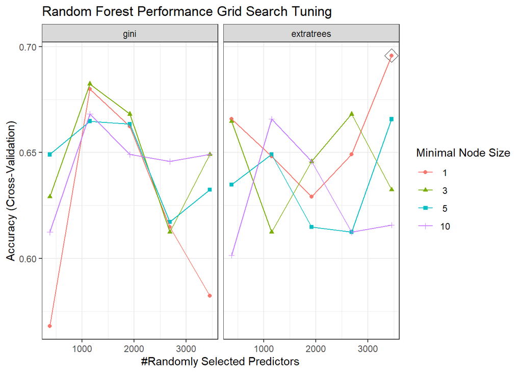

Figure 2. Visualize the Grid Search Performance

#### 2.4.1.3. Take a look at the hyperparameters of the best model.

```r
rfTuned$bestTune %>%
kable(
    format = "html",
    caption = "Table 3. Results of the Grid Search on Random Forest") %>%
    kable_styling(bootstrap_options = c("hover", full_width = F))
```

Table 3. Results of the Grid Search on Random Forest

|  | mtry | splitrule | min.node.size |
| --- | --- | --- | --- |
| 37 | 3454 | extratrees | 1 |

#### 2.4.1.4. Fit the best model’s hyperparameters to the test data.

```r
rfTuned <- train(Treatment ~.,
               data = train,
               method = "ranger",
               trControl = kFoldCtrl,
               tuneGrid = rfTuned$bestTune)   ## Use the best model
```

#### 2.4.1.5. Make the new predictions to assess accuracy.

```r
pred.test.rf <- predict(rfTuned, test, type = "raw")  ## type is now 'raw'
# Store the confusion matrix
confMatTuned <- confusionMatrix(pred.test.rf, test$Treatment)
```

#### 2.4.1.6. Compare the three confusion matrices.

```r
compareConfusion(confusionList = list(confMat, confMatCV, confMatTuned)) %>%
    kable(
    format = "html",
    caption = "Table 4. Comparing Accuracy - Random Forest") %>%
    kable_styling(bootstrap_options = c("hover", full_width = F))
```

Table 4. Comparing Accuracy - Random Forest

| Metric | Confusion Matrix 1 | Confusion Matrix 2 | Confusion Matrix 3 |
| --- | --- | --- | --- |
| Accuracy | 0.7142857 | 0.7142857 | 0.5714286 |
| Kappa | 0.4285714 | 0.4285714 | 0.1428571 |
| AccuracyLower | 0.4189647 | 0.4189647 | 0.2886094 |
| AccuracyUpper | 0.9161107 | 0.9161107 | 0.8233889 |
| AccuracyNull | 0.5000000 | 0.5000000 | 0.5000000 |
| AccuracyPValue | 0.0897827 | 0.0897827 | 0.3952637 |
| McnemarPValue | 0.6170751 | 0.1336144 | 0.6830914 |

#### **Question 13**: What impact did hyperparameter tuning with the grid search have on model performance compared to both the OOB and 10-fold CV with auto-tuning?

**Note on methodology**: As I mentioned above, there is no parameter for the number of trees that we could tune in the search grid. Why not? It’s because we used the `train()` function from the `caret` package. `train()` is what is called a **wrapper function**, which means that we may be somewhat stuck using what’s available to us in the function. But what if we want to tune hyperparameters that are available through that wrapper function? We would need to switch our tactics. We could either write a **custom function or loop** to do it, or we could modify the function in `caret`. Wait, we can do that?! Yep!

#### **Question 14**: Use the `modelLookup` function to help you figure out what hyperparameters are available for the `rf` vs. `ranger` methods for performing random forest algorithm with `caret`. What are the key differences you observce in the hypers you can tune?

```r
modelLookup("ranger")
```

```
##    model     parameter                         label forReg forClass probModel
## 1 ranger          mtry #Randomly Selected Predictors   TRUE     TRUE      TRUE
## 2 ranger     splitrule                Splitting Rule   TRUE     TRUE      TRUE
## 3 ranger min.node.size             Minimal Node Size   TRUE     TRUE      TRUE
```

```r
modelLookup("rf")
```

```
##   model parameter                         label forReg forClass probModel
## 1    rf      mtry #Randomly Selected Predictors   TRUE     TRUE      TRUE
```

MH > The hyperparameters available in `rf` are only mtry, whereas for `ranger`, there is `mtry`, `splitrule` and `min.node.size`.

### 2.4.2 Grid Search Using a Customized `caret` Method

#### 2.4.2.1. Write a customized `caret` method for random forest using the `ranger` method.

#### **Question 15**: Add comments above, as best you can, to our custom function. In your own words, what exactly does this function do? Why are we writing a customized function? (**Hint**: I told you above!)

MH > This function allows us to tune additional hyerparameters, define exactly ho the model is trained and gives us additional flexibility and control over the normal tuning done withing `caret`.

#### 2.4.2.2. Run the customized method.

**NOTE**: This takes about 12 min to run on 16gb of RAM. This is exactly why we are doing caching for this assignment. Otherwise, your report will take forever to re-knit.

```r
## Run the custom method setting the hyperparameters we want to use
customRF <- makeCustomMethod(paramList = c("mtry",
                                           "num.trees",
                                           "min.node.size",
                                           "splitrule"),
                             methodName = "ranger")

## Now expand the search grid
searchGrid <- expand.grid(.mtry = floor(ncol(train) * c(.05, .15, .25)),
                        .num.trees = c(50, 200),
                        .min.node.size = c(1, 5, 10, 20),
                        .splitrule = "gini"
                        )
## Now run the RF with the custom tuned hypers and the new search grid
customTuned <- train(y = train$Treatment, x = train,
                method = customRF,
                metric = "Accuracy",
                tuneGrid = searchGrid,
                trControl = kFoldCtrl)
```

#### **Question 16**: Did you catch that I am setting `.splitrule = gini` explicitly? Why do you think I made this choice?

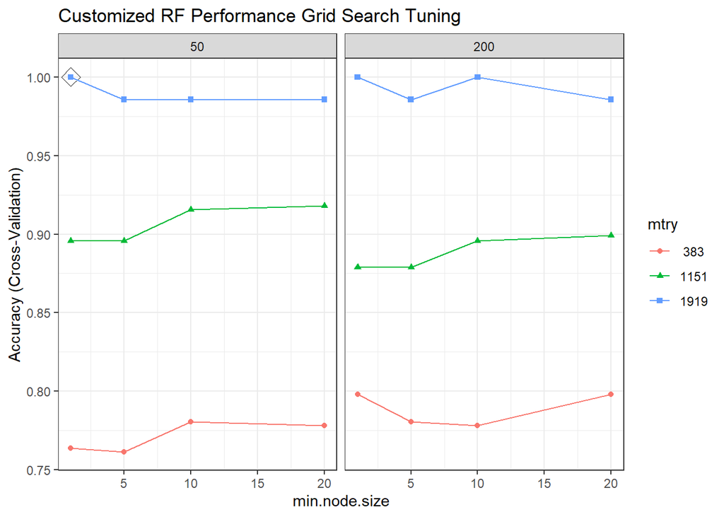

Figure 3. Visualize the Customized Grid Search Performance

#### 2.4.2.3. Take a look at the hyperparameters of the best model.

```r
customTuned$bestTune %>%
kable(
    format = "html",
    caption = "Table 4. Results of the Customized Grid Search on Random Forest") %>%
    kable_styling(bootstrap_options = c("hover", full_width = F))
```

Table 4. Results of the Customized Grid Search on Random Forest

|  | mtry | num.trees | min.node.size | splitrule |
| --- | --- | --- | --- | --- |
| 17 | 1919 | 50 | 1 | gini |

#### 2.4.2.4. Refit the best model’s hyperparameters to the test data set.

```r
newTuned <- train(Treatment ~.,
               data = train,
               method = customRF,
               trControl = kFoldCtrl,
               tuneGrid = customTuned$bestTune)
```

#### 2.4.2.5. Make the new predictions to assess accuracy.

```r
pred.test.rf <- predict(newTuned, test, type = "raw")
# Store the confusion matrix
confMatTuned2 <- confusionMatrix(pred.test.rf, test$Treatment)
```

#### 2.4.2.6. Compare the four confusion matrices.

Table 4. Comparing Accuracy - Random Forest

| Metric | Confusion Matrix 1 | Confusion Matrix 2 | Confusion Matrix 3 | Confusion Matrix 4 |
| --- | --- | --- | --- | --- |
| Accuracy | 0.7142857 | 0.7142857 | 0.5714286 | 0.7857143 |
| Kappa | 0.4285714 | 0.4285714 | 0.1428571 | 0.5714286 |
| AccuracyLower | 0.4189647 | 0.4189647 | 0.2886094 | 0.4920243 |
| AccuracyUpper | 0.9161107 | 0.9161107 | 0.8233889 | 0.9534207 |
| AccuracyNull | 0.5000000 | 0.5000000 | 0.5000000 | 0.5000000 |
| AccuracyPValue | 0.0897827 | 0.0897827 | 0.3952637 | 0.0286865 |
| McnemarPValue | 0.6170751 | 0.1336144 | 0.6830914 | 1.0000000 |

#### **Question 18**: How well did hyperparameter tuning with the number of trees and the new grid search perform? Are we seeing sufficient improvement to continue down this path?

**Hint**: Make sure to check model stability again as well by looking at the performance across folds, even though I didn’t do that for you.

MH

```r
#Checking fold accuracy for newTuned model
newTuned$resample
```

```
##     Accuracy      Kappa Resample
## 1  0.5714286  0.1600000   Fold01
## 2  0.8000000  0.5454545   Fold02
## 3  0.8333333  0.6666667   Fold03
## 4  1.0000000  1.0000000   Fold04
## 5  0.3333333 -0.3333333   Fold05
## 6  0.3333333 -0.3333333   Fold06
## 7  0.6666667  0.3333333   Fold07
## 8  0.6666667  0.4000000   Fold08
## 9  0.8333333  0.6666667   Fold09
## 10 0.6666667  0.3333333   Fold10
```

### 2.4.3 Random Search

A random search is where we randomly choose hyperparameters and, based on an initial set of random values, iteratively search until we get closer and closer to the best fit. Now, at this point we might also consider performing a random search in addition to the grid search; however, as we can see that we are generally STILL seriously under-performing, let’s table that idea and put our efforts somewhere we will hopefully see a bigger impact: **Nested Cross-Validation**.

## 2.5 Nested Cross-Validation

As we have already discussed in lecture and Demo_3, the norm in machine learning is to have a lot more observations ($n$) than the number of features ($P$). Although it is tempting to think the same thing here, remember that the columns here are not features but rather samples, giving us a $P >> N$ problem.

Whenever $P >> N$ as here, our typical approaches for cross-validation must change. We have several options, but here we will employ a **nested cross-validation** approach. Other options would include a hold out or leave-one-out, although with some caveats.

**You will find that this method is not employed as much as it should be yet in gene expression analysis.** Why? Conceptually, this may be a bit hard to understand - and ML methods are already really different from what is done with the conventional methods like `DESeq2`. Let’s go over what nested CV is to try to unpack this a little.

### 2.5.2 The `nestedcv` package

Although we can also execute this with custom functions or loops, it’s usually going to be far more expedient to leverage a pre-existing package. Here, we will use the `nestedcv` package.

`nestedcv` partitions the dataset into outer and inner folds, with the default being 10-fold outer CV and 10-fold inner CV, also called **10 x 10 folds** CV. The inner-fold cross validation tunes the optimal hyperparameters for whatever model(s) are run. The model is then fitted on the whole inner-fold and tested against the left-out data from the outer-fold. This is repeated across all outer-folds. Then, the test predictions from the outer-folds are compared against the true results for the test outer-folds. The combined results give a measure of accuracy for the whole dataset as you are accustomed, e.g., either RMSE for regression or AUC for classification.

Lastly, a final round of cross-validation is performed on the whole dataset to determine hyperparameters to fit the final model to the whole data, which can be used for prediction with external data (which could be yet another test set you have withheld, for example, as we’ve been doing).

**Whew!**

Shall we try it?!?

### 2.5.3 Running a Nested CV

#### 2.5.3.1. Set a search grid and train the model using the `nestedcv.train()` function.

Note that the setup looks a little reminiscent of our customized `caret` function. That’s because the authors of this package are doing something similar, although they have improved the computational speed. We could do that too - **if** we wanted to write a package. Otherwise, we can just let ours run and take a coffee/tea break. :)

**IMPORTANT!**: We are not able to use $m_{try}$ as large as we are used to because we’re doing inner- and outer-folds. We lowered $m_{try}$ here as a result. If you are doing this on different data and you get an error, that’s something to look into!

**Note**: This took 14 mins on 16gb RAM, depending on what else I was asking my computer to do at the same time.

```r
searchGrid <- expand.grid(.mtry = floor(ncol(train) * c(0.01, 0.05, 0.10)),
                        .min.node.size = c(1, 5, 10),

                        .splitrule = "gini"
                        )
ncv <- nestcv.train(y = train$Treatment, x = train,
                    method = 'ranger',
                    tuneGrid = searchGrid,
                    savePredictions = "final")
```

```
## Fitting final model using CV on whole data
```

```
## Performing 10-fold outer CV, using 1 core
```

```
## Duration: 15.16305 mins
```

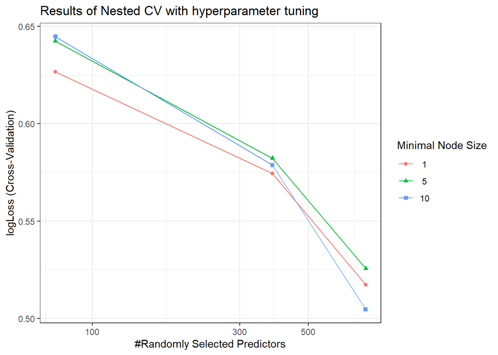

Figure 4. Visualize the Nested CV Performance on RF + Grid Search

#### **Question 19**: Notice that the y-axis is now **log-Loss** and not **accuracy**. You may need to do some digging, but can you figure out why? Citing sources can be helpful to ensure you’re on the right track!

**Note**: You’re going to see something really weird here…

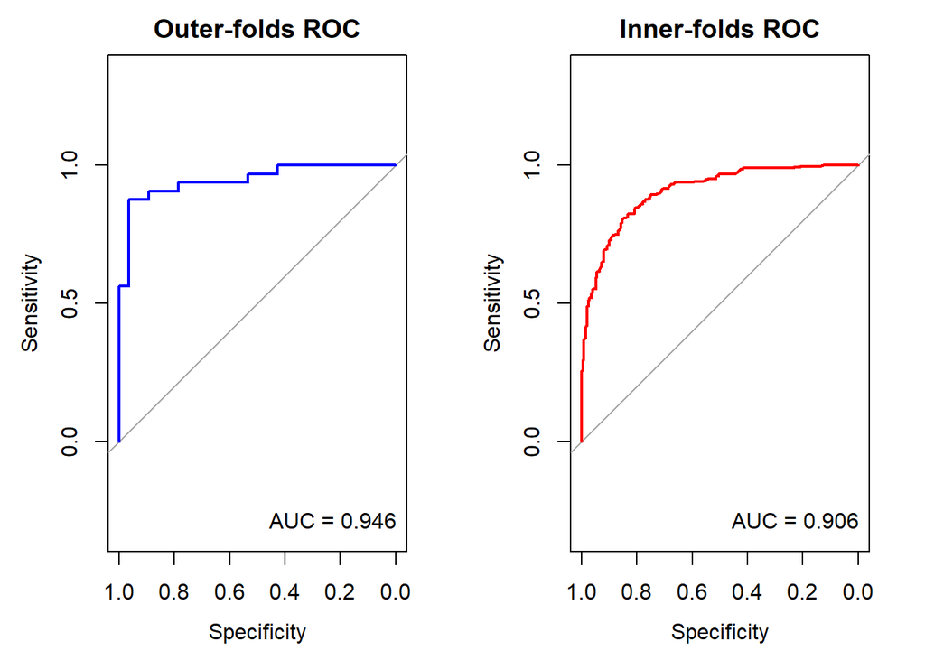

#### 2.5.3.3. Get final accuracy by fitting to the test data.

```r
preds <- predict(ncv,
                 newdata = test)
confusionMatrix(preds, test$Treatment)
```

```
## Confusion Matrix and Statistics
##
##           Reference
## Prediction Control Cold
##    Control       6    0
##    Cold          1    7
##
##                Accuracy : 0.9286
##                  95% CI : (0.6613, 0.9982)
##     No Information Rate : 0.5
##     P-Value [Acc > NIR] : 0.0009155
##
##                   Kappa : 0.8571
##
##  Mcnemar's Test P-Value : 1.0000000
##
##             Sensitivity : 0.8571
##             Specificity : 1.0000
##          Pos Pred Value : 1.0000
##          Neg Pred Value : 0.8750
##              Prevalence : 0.5000
##          Detection Rate : 0.4286
##    Detection Prevalence : 0.4286
##       Balanced Accuracy : 0.9286
##
##        'Positive' Class : Control
##
```

#### **Question 21**: Using help from generative AI or search engines, figure out how to assess the **stability** of the model across the nested folds. What conclusions can you draw? Write a 1-2 sentence conclusion for your stakeholders about whether or not you think the random forest is tuneable and what you’d recommend next.

DS > The way we can assess stability are visually and tracking different intervals with parameter values to see if there is a somewhat constant range with the model. We’ve found out there isn’t a consistant range like we’d hoped to have. We’ll need to jump back into our samples and try to gain more from there being errors with flucuations in results due to how small our observation size is.

#### 2.5.3.4. Grab the important features.

Even if you decided that model performance is still poor and that you’d not recommend continuing with the RF, let’s practice grabbing the important features so you have code to do it.

Table 5. Important Features from the Nested CV Grid Search on Random Forest

|  | MeanDecreaseGini |
| --- | --- |
| LOC100748421 | 6.267335 |
| LOC100745354 | 3.786693 |
| LOC100748062 | 3.659410 |
| LOC100749089 | 3.590366 |
| LOC100745817 | 3.465043 |
| LOC100747442 | 3.354427 |
| LOC100740663 | 3.000552 |
| LOC100740313 | 2.885104 |
| LOC100750201 | 2.789099 |
| LOC100742582 | 2.688020 |

#### 2.5.3.5. Compare our gene results to the ones out of `DESeq2`.

Remember, the ultimate goal was to see which ML method was getting us close to results from `DESeq2`, the respected, conventional method.

Let’s filter the nested CV random forest importance:

Now let’s compare that to what we got out of `DESeq2`.

**Note** that I am setting a log-fold change filter to 1. In other words… any gene! Am I going to get any credible results?

Table 6. Overlapping Features identified from DESeq and Nested CV Random Forest

| baseMean | log2FoldChange | lfcSE | stat | pvalue | padj | geneID | MeanDecreaseGini |
| --- | --- | --- | --- | --- | --- | --- | --- |
| 5169.769 | 1.118413 | 0.9344836 | 1.196824 | 0.231375 | 0.9999865 | LOC100747885 | 0.4697477 |

**IMPORTANT!** I have had this list reshuffle on me. I believe the issue is with the `rf_filter()` function we’re using, and is something to consider for reproducibility!

#### 2.5.3.6. Find out what our top gene from nested CV random forest does.

Although the gene list has shuffled a bit from run to run, I did want to give you an example of one gene that I keep seeing come up again and again and *one way* we might try to explore what these genes are and what they do. Because, at the end of the day, having a list of genes is rather dissatisfying if we want to know the underlying biology and mechanism of chill coma.

One of the genes that came up as the top important gene for me repeatedly was I went to [NCBI](https://www.ncbi.nlm.nih.gov), and just searched for **LOC100747964**. The gene should come up from *Bombus impatiens*, common Eastern bumblebee and it does. [UDP-N-acetylhexosamine pyrophosphorylase](https://www.ncbi.nlm.nih.gov/gene/?term=LOC100747964) seems to be involved in protein glycosylation and glycolipids, which is just a long way of saying it looks like it’s a gene that is differentially regulated during metabolism.

A second gene that came up frequently for me was **LOC100748162**, which is also a gene from *Bombus impatiens* and [encodes pancreatic lipase-related protein 2](https://www.ncbi.nlm.nih.gov/gene/?term=LOC100748162), another metabolism gene. So, it may suggest one of the physiological effects that happens to *B. impatiens* when it goes into chill-coma is an alteration in metabolism, which makes sense.

#### **Question 22**: Do you think we should we have any confidence in these results? Why or why not? Think about this from the perspective of what you would tell/advise your stakeholder.

# 3 Takeaways & Next Steps

## 3.1 Enter Phase 2 of this Project:

As we move forward with our benchmarking study, you have two choices. Choose your own adventure!

- **Path 1** - Potentially easier and more satisfying.

  Perform $k$-fold & nested CV Random Forest, as well as hyperparameter tuning, on a different VST from the 30-minute experiment only.

  If you decide to choose this adventure, you will use the VST data for the 30-min time point expression data only. You will also be given the `DESeq` results so you can use the `findOverlappingGenes()` function again to look at performance. Your task will be to take this vst, and work through all the same steps as in this first-half of the project. **Make sure to look at the important features at the end and comment on whether you have any confidence in your results!**
- **Path 2** - Potentially more challenging, and possibly dissatisfying.

  Ready to do go farther? Try performing $k$-fold & nested CV, as well as hyperparameter tuning, on SVM.

  If you choose this adventure, you will have the option to work through this same vst OR the 30-minute VST and your challenge is to apply SVM, including tuning the hyperparameters of **kernel**, **gamma**, and **cost**. Currently, we cannot get the important features out of nested cv SVM easily (alas - it needs another custom function!), so for this project you only need to engineer a best SVM model, discuss why you think it’s the best model, and what your next recommendations are.

# 4 Final Comments / Advice

- Make sure to use the template I provide on GitHub for the project, rather than adding on to this document. It will just get too long! **If you can’t upload the knitted file, just submit a note on Canvas that it wouldn’t knit and that yoour RMD is on on your Team GitHub.* I expect some folks may have difficulty knitting. Be patient, too. It might take a half-hour or longer.
- **Don’t forget!** Answer questions scattered throughout the Random Forest CV and Tuning Sections to ensure your understanding (you may copy these answers, without code, to your project document.)

**Files you need for the 30-min data will be found in the `data_30min` directory**:

1. `vst_30_min.Rdata` = the 30-min equivalent of the `vsData` object with the VST normalized read counts, formatted and ready to use as in this walk-through.
2. `vst_30_min.txt` = a text file version, which you likely do not need
3. `DESeq_on_30min_Data.Rmd` = an RMD file that was used to generate the 30-min data, plus some exploratory analysis. For the results see #4.
4. `DESeq_on_30_Data.html` = knitted file with some EDA and results to get you better acquainted to the data. Take a look! :)
5. `DESeqResults_30_min.Rdata` = the 30-min equivalent of the `DESeqResults` object that you can use with this walk-through.

**You will absolutely need to take a look at #4 to get you started. You will also want to use #1 and #5 for your analysis.**

# References

Love, Michael I., Wolfgang Huber, and Simon Anders. 2014. “Moderated Estimation of Fold Change and Dispersion for RNA-Seq Data with DESeq2.” *Genome Biology* 15 (12): 550. https://doi.org/10.1186/s13059-014-0550-8.

R Core Team. 2019. *R: A Language and Environment for Statistical Computing*. R Foundation for Statistical Computing. https://www.R-project.org.

Vabalas, Emma AND Poliakoff, Andrius AND Gowen. 2019. “Machine Learning Algorithm Validation with a Limited Sample Size.” *PLOS ONE* 14 (11): 1–20. https://doi.org/10.1371/journal.pone.0224365.

Verble, Kelton M., Ellen C. Keaveny, Sarthok Rasique Rahman, Matthew J. Jenny, Michael E. Dillon, and Jeffrey D. Lozier. 2024. “A Rapid Return to Normal: Temporal Gene Expression Patterns Following Cold Exposure in the Bumble Bee *Bombus Impatiens*.” *Journal of Experimental Biology* 227 (9): jeb247040. https://doi.org/10.1242/jeb.247040.